# Bayesian Statistics and MCMC...

A *very* brief intro to Bayesian Statistics for people who just want to use it to solve the Universe. Or those who think (correctly) that it's the cool kid in town.

*NOTE:* This presentation makes pretty heavy use of the awesome Jupyter notebook/actual book [Probabilistic Programming and Bayesian Methods for Hackers](https://github.com/CamDavidsonPilon/Probabilistic-Programming-and-Bayesian-Methods-for-Hackers).

[figure not shown]

## The Philosophy of Bayesian Inference

Bayesian Inference is:

- A way of assigning degree of *belief* to certain statements.
- Rarely are statements *certain*, they always have some degree of belief.
- Belief is *updated* by new evidence, in a rigorous way.
- Alternative to "traditional" *frequentist* view, which typically gives exact result.

Both frequentist and Bayesian viewpoints are useful, and *usually* give the same answer when the amount of data is very very large. Bayesian more natural if:

- Amount of data is small (which it *always* is).
- Probabilities of outcomes are required.
- Belief is being updated over time as evidence accumulates.

### Why Bayesian?

- It gears towards the probability of a statement (read "model") given the existence of a set of data (can't keep repeating trial runs of the Universe).
- It entirely naturally takes into account -- in a formalised way -- our *prior* knowledge/belief about a given model.
- It assumes that we can never be certain about a statement, but we *can* specify how high our belief is in it, and continually update that belief as new evidence arrives.

### Priors

**Imagine the toss of a coin. Someone tosses the coin 5 times, revealing 5 heads. What happens next?**

[figure not shown]

**Your instincts suggest, and Bayes confirms, that your estimation of your "friend" is an important factor to consider**

**This is a prior.**

## The Bayesian Framework

**Given a model $A$, how do we *update* our belief in $A$, given some data $D$?**

**Bayes' Theorem:**

$$ P(A|D) = \frac{P(D|A)P(A)}{P(D)}.$$

### Example 1: Coin Toss (from book)

$$ P(A|D) = \frac{P(D|A)P(A)}{P(D)}.$$

$$ P(A) \sim {\rm Uniform}(0,1). $$

$$ P(D|A) = p^{N_h}(1-p)^{N_t}. $$

$$P(D) = 2^{N_h+N_t}.$$

[figure not shown]

### Example 2: Simplest Gaussian

$$P(A=\mu) = {\rm constant}.$$

$$P(D|A=\mu) = \frac{1}{\sqrt{2\pi}\sigma^2} \exp(-\frac{(\vec{x} - \mu)^2}{2\sigma^2}). $$

$$P(D) = \int d\mu P(D|A=\mu) = 1.$$

So...

$$P(\mu|D) = P(D|\mu)$$

### Example 3: Unknown Spread.

$$P(\mu,\sigma) = \begin{cases} \exp\left(-\frac{(\mu-\mu_\mu)^2}{2\sigma_\mu^2}\right) & \sigma \in (a,b) \\ 0 & {\rm otherwise} \end{cases}. $$

$$ P(D) = \int d\mu \int d\sigma \prod_i \frac{e^{-(h_i - \mu)^2/2\sigma^2}}{\sqrt{2\pi\sigma^2}} P(\mu,\sigma).$$

**Not analytically tractable! Where to from here?**

## MCMC

**Why not other possibilities?**

- Pure integration only works for low number of parameters, simple likelihood.
- Integration still doesn't give quantities of interest -- mean, median, mode, variance etc.
- Could just maximise $\mathcal{L}$ (reasonably quick), but only gives one point estimate.

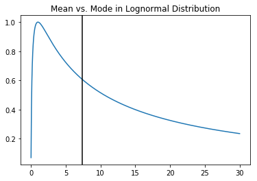

```python
x = np.linspace(0.01,30,1000)
plt.plot(x, np.exp(-(np.log(x) - 0.0)**2/(2*2.0**2)))
plt.axvline(np.exp(0 + 2**2/2.), color='k')
plt.title("Mean vs. Mode in Lognormal Distribution");
```

### Why MCMC?

#### MCMC is a smart integrator

- Scales ~$N$ rather than ~$x^N$.
- *Samples* the space.
- Samples provide *very easy* way of getting posterior estimates (mean, median, variance etc.)
- Represents entire multi-variate dist. of posterior.

### How MCMC Works

**Proto-typical algorithm (metropolis-hastings):**

1. Choose set of parameters $\theta_0$
2. Evaluate $P(\theta_0|D)$
3. Choose $\theta_1$ (and evaluate $P(\theta_1|D)$).
4. If $P(\theta_1|D)>P(\theta_0|D)$, keep $\theta_1$ and set $\theta_0=\theta_1$ (repeat)
5. Else If $P(\theta_1|D)<P(\theta_0|D)$, keep with probability $P(\theta_1|D)/P(\theta_0|D)$, otherwise discard and try again.

#### Properties of MCMC

**Irrelevance of the tricky term:**

$$ \frac{P(D|A_1) P(A_1)}{P(D)} / \frac{P(D|A_2)P(A_2)}{P(D)} \equiv \frac{P(D|A_1) P(A_1)}{P(D|A_2) P(A_2)}. $$

**Memoryless**

Algorithm only cares about current and next steps, does not "remember" previous steps (Markov Chain).

**Choice of Step**

## *Doing* MCMC

- Never use your own step method, better ones exist.
- Two general ways of doing the "mechanics":
  1. Black-box
  2. Probabilistic Programming.

**General Workflow:**

1. Specify model (i.e. $\ln P(D|A)$)
2. Specify (log) priors
3. Specify starting values.
4. Specify number of iterations you want to sample.
5. Pass all these to the MCMC machine.
6. Assess whether returned chains are converged.
7. Make some plots and summary statistics.

Steps 1 and 2 are dependent on what kind of code you're using ('black box' or 'probabilistic programming').

### Example: Black-box

In this kind of code, all you need to define is a single function which takes data and parameters, and spits out the log of the posterior. Everything inside the function is up to you. `emcee` is an example.

A general setup may look like this:

```python
def log_prob_data_given_model(model_parameters, data):
    ...
    return log_prob

def log_prior(model_parameters):
    return log(norm(model_parameters))

def lnL(model_parameters, data):
    return log_prob_data_given_model(model_parameters, data) + log_prior(model_parameters)

big_chain = call_mcmc(initial_param_values,
                      data,
                      lnl_function = lnL,
                      n_iterations)

ensure_converged(big_chain)

print(summary(big_chain))

plot(big_chain)
```

## Practical Concerns

### Constructing a Likelihood

- The guts of doing Bayesian stats.
- How to construct the `log_prob_data_given_model()` function?

**Consider a *generative model***

- How would you generate the data itself?
- Track each step of the stochastic process, specify each assumption.

#### Example: Dark Matter Haloes (I)

\begin{align} m &\sim {\rm Gamma}(\alpha, \beta) \\ m_{\rm obs} &\sim {\rm LogNorm}(\mu=m, \sigma = A m^{-\gamma}). \end{align}

*Not* fully specified!

#### Example: Dark Matter Haloes (II)

**Gotta get our parameters from somewhere:**

\begin{align} \alpha &\sim {\rm Uniform}(0,1) \\ \beta &\sim {\rm Uniform}(0,2) \\ A &\sim \mathcal{N}(100,3) \\ \gamma &\sim \mathcal{N}(0,1)\\ m &\sim {\rm Gamma}(\alpha, \beta) \\ m_{\rm obs} &\sim {\rm LogNorm}(\mu=m, \sigma = A m^{-\gamma}). \end{align}

#### Example: Dark Matter Haloes (III: Going too far)

**Nothing stops us from drawing parameters from distributions with parameters from distributions from ...**

\begin{align} a &\sim {\rm Uniform}(0,1) \\ \alpha &\sim {\rm Uniform}(0,a) \\ \beta &\sim {\rm Uniform}(0,2) \\ A &\sim \mathcal{N}(100,3) \\ \gamma &\sim \mathcal{N}(0,1)\\ m &\sim {\rm Gamma}(\alpha, \beta) \\ m_{\rm obs} &\sim {\rm LogNorm}(\mu=m, \sigma = A m^{-\gamma}). \end{align}

**At some point, it makes no difference, so just stop.**

#### Example: Dark Matter Haloes with "black box"

The generative model can be directly turned into the function we require (in python speak):

```python
from scipy.stats import norm, gamma, uniform, lognorm

def lnL(model_parameters, data):
    alpha,beta,A,gamma, m_intrinsic = model_parameters

    lnL = 0

    lnL += np.log(uniform(0,1).pdf(alpha))
    lnL += np.log(uniform(0,2).pdf(beta))
    lnL += np.log(norm(100,3).pdf(A))
    lnL += np.log(norm(0,1).pdf(gamma))

    lnL += np.sum(np.log(gamma(alpha,beta).pdf(m_intrinsic)))
    lnL += np.sum(np.log(lognorm(m_intrinsic, A*m_intrinsic**-gamma)))

    return lnL
```

#### Example: Dark Matter Haloes with Probabilistic Programminc (`PyMC3`)

```python
import pymc3 as pm

data = <read_in_observed_masses>
with pm.Model() as model:
    # Simple parameters
    alpha = pm.Uniform("alpha", lower=0, upper=1)
    beta = pm.Uniform("beta", lower=-1, upper=1)
    A = pm.Normal("A", mean=100, sd=3.)
    gamma = pm.Normal("beta", mean=0, sd=1)

    # The intrinsic masses (really just a bunch of parameters)
    m_intrinsic = pm.Gamma("m_intrinsic", alpha=alpha, beta=beta, shape=len(data))

    # The observed masses (set to being observed as data)
    m_observed = pm.Normal("m_observed", mu = np.log(m_intrinsic), sd = 3., observed=data)
```

#### Full Example: Heights with `PyMC3`

```python
import pymc3 as pm
import numpy as np

def generate_data(N):
    mean = 1.7
    sd = 0.2
    return np.random.normal(loc=mean, scale=sd, size=N)

data = generate_data(150)

with pm.Model() as model:
    mean = pm.Normal("mean", mu = 1.4, sd = 0.5, testval=1.3)
    sd = pm.Uniform("sd", lower=0.05, upper=0.3, testval = 0.06)

    heights = pm.Normal("heights", mu=mean, sd=sd, observed=data)

    step = pm.Metropolis()
    chains = pm.sample(20000, step=step, njobs=4)
```

[output not shown]

### Diagnosing Convergence

#### Burn-in

- Chains may not start "in" the posterior, and take time to truly get inside it.
- This period known as burn-in.

Can heuristically identify:

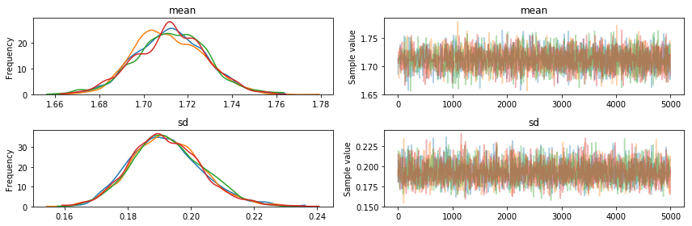

```python
pm.traceplot(chains[:5000]);
```

**Rule-of-thumb is cut out first half.**

```python
# Get rid of first half of samples to "burn in"
chains = chains[10000:]
```

#### Correlation of Samples

- Close samples are correlated
- Can perform "thinning", but usually no need to (numbers outweight correlation).

Check out how many samples you need before you remove correlation:

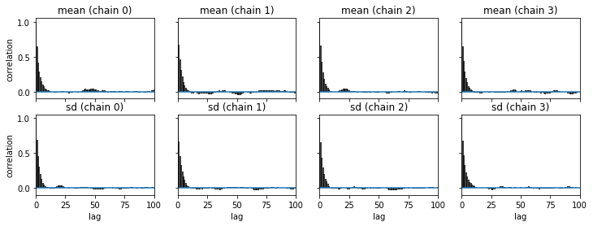

```python
pm.plots.autocorrplot(chains);
```

#### Number of samples

Two popular options exist:

```
1. Integrated auto-correlation time (``emcee``'s preferred option)
    * Use ~$50\tau$ samples
2. Gelman-Rubin statistic (good when you have multiple chains)
    * Ensure $\hat{R}<1.01$
```

```python
pm.summary(chains)
```

|  | mean | sd | mc_error | hpd_2.5 | hpd_97.5 | n_eff | Rhat |
| --- | --- | --- | --- | --- | --- | --- | --- |
| mean | 1.711667 | 0.015686 | 0.000168 | 1.681214 | 1.742864 | 8221.0 | 1.000181 |
| sd | 0.192369 | 0.011328 | 0.000120 | 0.171429 | 0.215154 | 7712.0 | 1.000096 |

### Interpreting an MCMC chain

**Key difference to single-point estimators (eg. chi-square minimization) is that the posteriors per parameters are *marginal*.**

- Other parameters are *integrated over*
- Provides final distribution for that parameter, given complete uncertainty of all other parameters.
- Joint-marginalised PDF for two parameters shows covariance.

**Some useful summary plots are 1D histograms/KDEs**

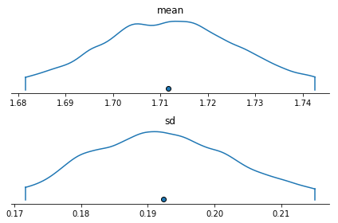

```python
pm.plots.densityplot(chains);
```

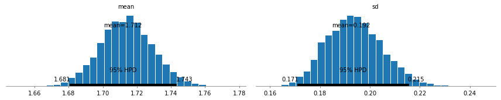

```python
pm.plot_posterior(chains);
```

One of the most highly useful plots to make from an MCMC run is the so-called "corner" plot. Packages like `corner` and `ChainConsumer` can make these plots for you (eg. chainconsumer):

[figure not shown]

## Tips

After actually creating the likelihood model, the most energy-consuming part of doing MCMC is making sure it's telling you something useful. Lots of things can go wrong, even if your model is correct, and we've hinted at a few already:

- your model could be incorrect
- your prior could be poor
- how do you know if your model is a good one?

### Model Correctness

- Usually can't say if model is definitely "correct"
- *Can* say it is definitely *incorrect.*

**Usually comes down to choosing wrong kind of distribution, eg.:**

- if the variable is bounded above 0 (or some other threshold). Then the Gaussian *must* be wrong. Try a log-normal.
- if the variable is discrete (or some scaling of a discrete number). Then the Gaussian *must* be wrong. Try a Poisson, or something similar.
- if the variable is skewed, try a distribution that can be skewed (eg. lognormal).

### Priors

Two bad things to do with priors:

**1. Not specify one at all**

- By default, prior is uniform over entire real line.
- This is
  1. Improper
  2. Almost never true
  3. Not what you think it is, in high dimensions
  4. Covering up information in the model.

**2. Not testing its impact.**

- Priors *are* subjective, which is good.
- We'd like the data to dominate the prior.
- Should explicitly test for this.

### Is the model a good one?

- Ability to find best parameters does *not* imply a good model was chosen.
- Check heuristically by generating data from posterior (not just at best parameters).
- Similar to plotting best-fit curve against data.

If a finite number of different models are known about/under consideration, they can be more formally compared. *This is not trivial, and you'll have to do more reading yourself.* Basic ideas:

- Domain of Bayesian Model Selection.
- Bayes' is very natural way to answer this question, with in-built "Occams Razor".
- Requires the other factor we ignored ($P(D)$), called the "Bayes Factor":

$$ B = \frac{P(M_1)}{P(M_2)} \frac{\int d\theta_1 f(D|\theta_1) P(\theta_1)}{\int d\theta_2 f(D|\theta_2) P(\theta_2)}. $$

- B>1 supports $M_1$.
- Very tricky to calculate, but supported in principle in `PyMC3`.

#### Example: Height Example Model Comparison

We need to use a different step method (Sequential Monte Carlo, SMC):

```python
from pymc3.step_methods import smc

with model:
    smc_trace = smc.sample_smc(n_steps=2000,
                               n_chains=100,
                              n_jobs=1, homepath='/home/steven/Documents/TutesAndLectures/')
```

Now run a second model, which assumes a Student-T distribution with unknown shape, $\nu$:

```python
with pm.Model() as model2:
    mean = pm.Normal("mean", mu = 1.4, sd = 0.5)
    sd = pm.Uniform("sd", lower=0.05, upper=0.3)
    nu = pm.Uniform("nu", lower=0.05, upper=5)

    heights = pm.StudentT("heights", nu=nu, mu=mean, sd=sd, observed=data)

    smc_trace = smc.sample_smc(n_steps=2000,
                               n_chains=100,
                               n_jobs=1, homepath='/home/steven/Documents/TutesAndLectures/model2')
```

[output not shown]

Compare marginal likelihoods (i.e. get the Bayes Factor):

```python
model.marginal_likelihood/model2.marginal_likelihood
```

```
17.668814320416594
```

**Note: it's unclear how robust this result is. Take with a grain of salt.**

## Conclusions

#### Some useful resources

- PyMC3 Docs
- [emcee docs](http://dfm.io/emcee/current/user/line/)
- [Probabilistic Programming and Bayesian Methods for Hackers](https://github.com/CamDavidsonPilon/Probabilistic-Programming-and-Bayesian-Methods-for-Hackers)
- [Stan Docs](https://github.com/stan-dev/stan/releases/download/v2.17.0/stan-reference-2.17.0.pdf)

#### Some good exercises

1. Write your own Metropolis-Hastings algorithm.
2. Try something like the height's example in this presentation.
3. What is the log-likelihood for a set of data points which follow an arbitrary 1D model: $y = f(x) + \mathcal{N}(0, \sigma)$? (i.e. where each point has Gaussian noise?), and what is it equivalent to?
4. Write down the likelihood for a similar problem to (3), but where there may be some observational uncertainty on $x$.